# Inside Context Memory

> This notebook focuses on context memory inside the rooms.

# 1 Overview of the data

The rooms were separated into *Familiar* and *Novel* groups. Participants explored the *Familiar* group at the beginning of the experiment. In the encoding task, they visisted both *Familiar* and *Novel* groups. Their context memory (i.e., in which room they saw the item) was tested in the memory test the next day of the encoding task. **Novelty benefits** on the context memory are examined by comparing the memory performance between the *Familiar* and *Novel* groups.

Participants were also asked to rate how curious they felt about the room. The higher the rating is means they felt more curious about the room. Context memory as a function of curiosity rating was also examined for **curiosity benefits**.

Questionnaires on personal traits regarding curiosity were also administered to participants before the encoding task (i.e., PC and EC). Scores on these questionnaires might be able to predict the context memory or its relationship with curiosity rating.

In the encoding task, there were 6 objects in each room. It is possbile that the context memory for the object to some extent depends on the order in which the object was seen. For example, it may be easier to remember where the first and last objects were seen as compared to those in the middle.

# 2 Individual performance

## 2.1 An overview of individual context memory performance as a function of room.

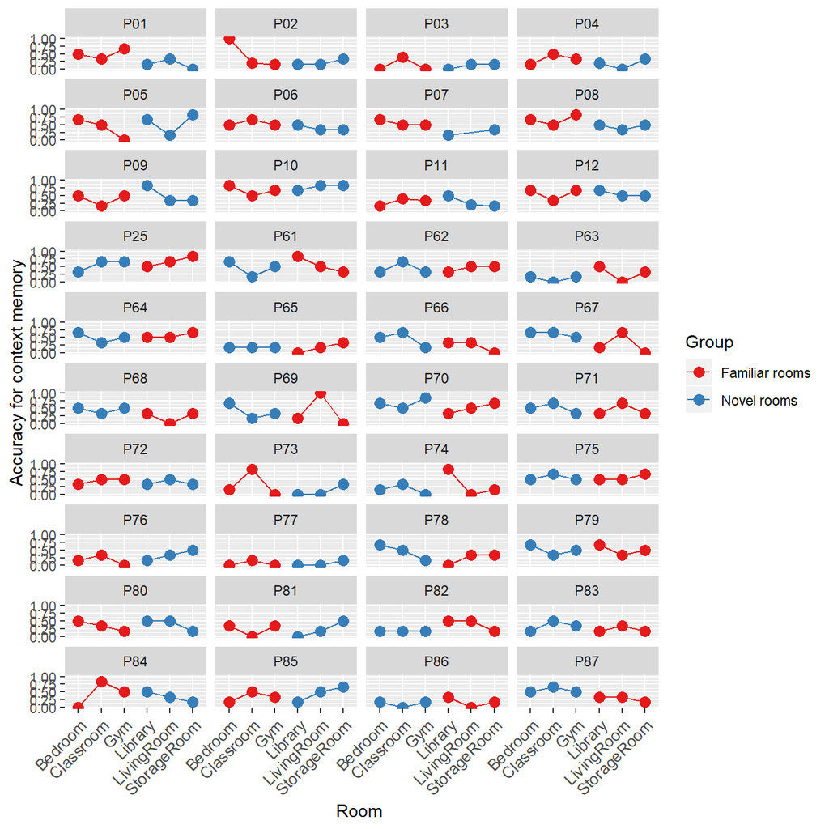

Figure1. Mean accuracy for context memory respectively for each room and each individual participant.

# 3 Novelty Benefits

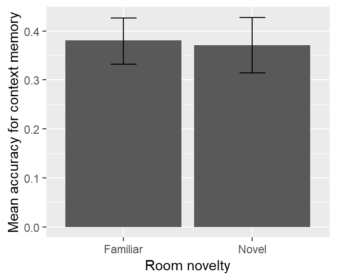

Figure4. Mean accuracy for context memory respectively for Familiar and Novel rooms.

```
##
##  Paired t-test
##
## data:  MeanContextAccuracy by Group
## t = 0.38322, df = 39, p-value = 0.7036
## alternative hypothesis: true difference in means is not equal to 0
## 95 percent confidence interval:
##  -0.04218676  0.06190898
## sample estimates:
## mean of the differences
##             0.009861111
```

## 3.1 Context memory as a function of item order

### 3.1.1 Visualise the data

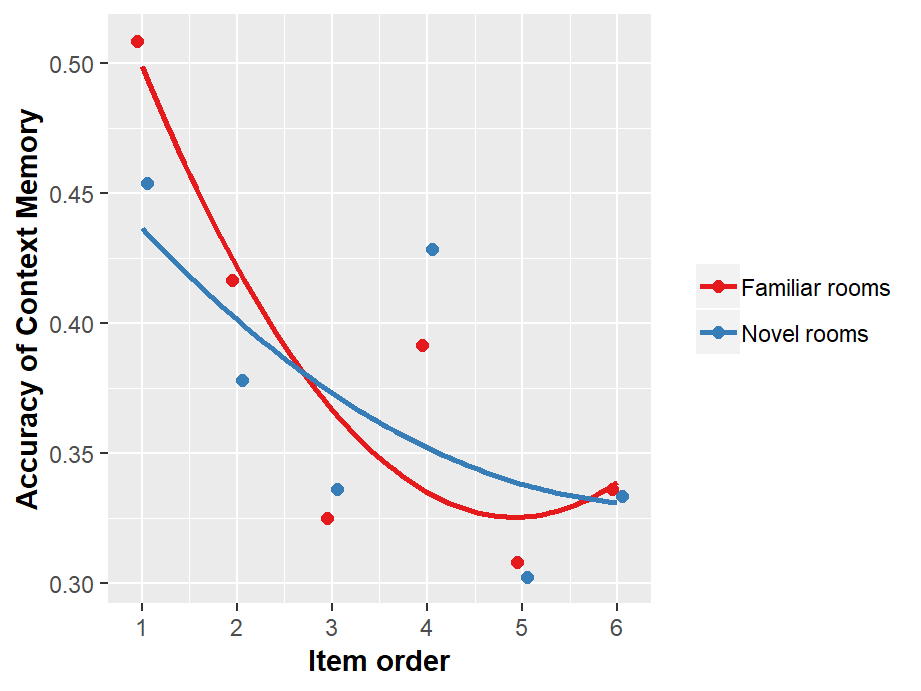

Figure 5. Mean accuracy of context memory for items at each order (i.e., 1st, 2nd, 3rd, etc), respectively for familiar and novel rooms.

### 3.1.2 Testing novelty effects by fitting mixed models

Build models with context memory accuracy as $y$ and examine effects of item order and novelty by comparing the models.

- `baseline.context` is the model with only an intercept.
- `order.model.linear.1` is the model with $\small ItemOrder$ included, showing the effects of item order.
- `order.model.linear.2` is the model allowing the slope (i.e., relationship between context memory and item order) varying across participants.
- `order.model.quad.1` and `order.model.quad.2` repectively included $\small ItemOrder^2$ and related random effects.
- `novelty.model.1` is the model with $\small Group$ (i.e., *familiar* and *novel* rooms) included, examining the effects of novelty of the rooms on the intercept (i.e., mean context memory accuracy at the 1st order or overall if no difference in slope).
- `novelty.model.2` is the model with interaction between $\small Group$ and $\small ItemOrder$ included, examining the effects of novelty on how context memory accuracy changes as a function of item order.
- `novelty.model.3` included interaction between $\small Group$ and $\small ItemOrder^2$ for inestigating whether the pattern changes between *familiar* and *novel* groups.

```
##                      Model df      AIC      BIC    logLik   Test   L.Ratio
## baseline.context         1  4 1945.964 1967.020 -968.9818
## order.model.linear.1     2  5 1934.158 1960.478 -962.0792 1 vs 2 13.805325
## order.model.quad.1       3  6 1934.062 1965.646 -961.0311 2 vs 3  2.096047
## novelty.model.1          4 14 1949.221 2022.918 -960.6106 3 vs 4  0.841057
## novelty.model.2          5 15 1950.610 2029.570 -960.3049 4 vs 5  0.611308
## novelty.model.3          6 16 1952.024 2036.249 -960.0121 5 vs 6  0.585696
##                      p-value
## baseline.context
## order.model.linear.1  0.0002
## order.model.quad.1    0.1477
## novelty.model.1       0.9991
## novelty.model.2       0.4343
## novelty.model.3       0.4441
```

#### 3.1.2.1 Parameter estimation for the complete model

```
## Linear mixed-effects model fit by maximum likelihood
##  Data: Encoding.Recall.Old[!SubjectNo %in% bad.ps.less.strict]
##        AIC      BIC    logLik
##   1952.024 2036.249 -960.0121
##
## Random effects:
##  Formula: ~1 + ItemOrder + I(ItemOrder^2) | SubjectNo
##  Structure: General positive-definite, Log-Cholesky parametrization
##                StdDev      Corr
## (Intercept)    0.177364098 (Intr) ItmOrd
## ItemOrder      0.039275339 -0.880
## I(ItemOrder^2) 0.005605025  0.685 -0.898
##
##  Formula: ~1 + Group | SubjectNo %in% SubjectNo
##  Structure: General positive-definite, Log-Cholesky parametrization
##             StdDev       Corr
## (Intercept) 5.901315e-05 (Intr)
## GroupNovel  5.572595e-02 0.819
## Residual    4.639019e-01
##
## Fixed effects: ContextAccuracy ~ ItemOrder + I(ItemOrder^2) + Group + ItemOrder:Group +      I(ItemOrder^2):Group
##                                Value  Std.Error   DF   t-value p-value
## (Intercept)                0.5962264 0.08104936 1383  7.356337  0.0000
## ItemOrder                 -0.1090397 0.05020410 1383 -2.171928  0.0300
## I(ItemOrder^2)             0.0109333 0.00703884 1383  1.553278  0.1206
## GroupNovel                -0.1180717 0.10806192 1383 -1.092630  0.2747
## ItemOrder:GroupNovel       0.0641105 0.07054396 1383  0.908802  0.3636
## I(ItemOrder^2):GroupNovel -0.0075623 0.00988195 1383 -0.765268  0.4442
##  Correlation:
##                           (Intr) ItmOrd I(ItO^2) GrpNvl ItO:GN
## ItemOrder                 -0.905
## I(ItemOrder^2)             0.824 -0.978
## GroupNovel                -0.660  0.650 -0.596
## ItemOrder:GroupNovel       0.617 -0.701  0.686   -0.928
## I(ItemOrder^2):GroupNovel -0.566  0.686 -0.701    0.851 -0.979
##
## Standardized Within-Group Residuals:
##        Min         Q1        Med         Q3        Max
## -1.6254496 -0.8079138 -0.5332395  1.1276832  1.8039658
##
## Number of Observations: 1428
## Number of Groups:
##                  SubjectNo SubjectNo.1 %in% SubjectNo
##                         40                         40
```

```r
#### Parameter estimation for the optimal model
summary(order.model.quad.1, correlation = FALSE)
```

[output not shown]

### 3.1.3 Collapse the order

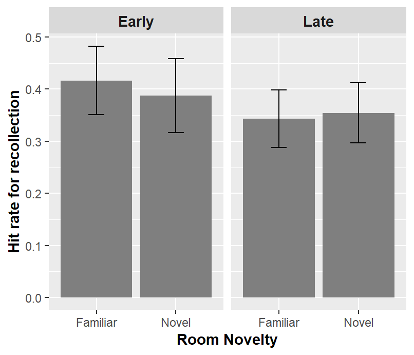

#### 3.1.3.1 Stats on it

```
## Linear mixed-effects model fit by maximum likelihood
##  Data: Encoding.Recall.Old.Collapsed.Grp
##         AIC       BIC   logLik
##   -88.68696 -64.08557 52.34348
##
## Random effects:
##  Formula: ~1 | SubjectNo
##         (Intercept)
## StdDev:   0.1213724
##
##  Formula: ~1 | Group %in% SubjectNo
##         (Intercept)
## StdDev:  0.05552884
##
##  Formula: ~1 | ItemOrderType %in% Group %in% SubjectNo
##         (Intercept)   Residual
## StdDev:   0.1326403 0.04646335
##
## Fixed effects: ContextAccuracy ~ Group * ItemOrderType
##                                   Value  Std.Error DF   t-value p-value
## (Intercept)                   0.4166667 0.03103637 78 13.425109  0.0000
## GroupNovel                   -0.0291667 0.03422080 39 -0.852308  0.3992
## ItemOrderTypeLate            -0.0732639 0.03182668 78 -2.301964  0.0240
## GroupNovel:ItemOrderTypeLate  0.0402778 0.04500972 78  0.894868  0.3736
##  Correlation:
##                              (Intr) GrpNvl ItmOTL
## GroupNovel                   -0.551
## ItemOrderTypeLate            -0.513  0.465
## GroupNovel:ItemOrderTypeLate  0.363 -0.658 -0.707
##
## Standardized Within-Group Residuals:
##         Min          Q1         Med          Q3         Max
## -0.67546295 -0.18267289 -0.00974417  0.17906058  0.82301552
##
## Number of Observations: 160
## Number of Groups:
##                               SubjectNo
##                                      40
##                    Group %in% SubjectNo
##                                      80
## ItemOrderType %in% Group %in% SubjectNo
##                                     160
```

# 4 Curiosity Benefits

We predicted that the accuracy of context memory should increase as the curiosity rating increases.

## 4.1 Mean accuracy of context memory as a function of curiosity rating

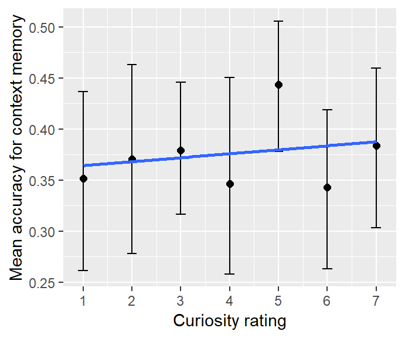

Figure 7. Mean accuracy for context memory as a function of curiosity rating.

### 4.1.1 Testing the relationship between mean accuracy of context memory and curiosity rating

Build models with context memory accuracy as $y$ and examine effects of curiosity rating by including it into the model and then comparing the model fits.

- `baseline.rating` is the model with only an intercept, showing no change in context memory as a function of curiosity rating.
- `rating.intercept` is the model with $\small CuriosityRating$ included, showing the effects of curiosity rating.
- `rating.slope` is the model allowing the slope (i.e., relationship between context memory and curiosity rating) varying across participants.

```
##                  Model df       AIC        BIC   logLik   Test   L.Ratio
## baseline.rating      1  3 -29.32661 -18.897217 17.66330
## rating.intercept     2  4 -27.65131 -13.745452 17.82565 1 vs 2 0.3246981
## rating.slope         3  6 -23.64340  -2.784618 17.82170 2 vs 3 0.0079067
##                  p-value
## baseline.rating
## rating.intercept  0.5688
## rating.slope      0.9961
```

#### 4.1.1.1 Parameter estimates in the complete model

```r
summary(rating.slope)
```

```
## Linear mixed-effects model fit by maximum likelihood
##  Data: InsideObjectsMemory[!SubjectNo %in% bad.ps.less.strict]
##        AIC       BIC  logLik
##   -23.6434 -2.784618 17.8217
##
## Random effects:
##  Formula: ~1 + CuriosityRating | SubjectNo
##  Structure: General positive-definite, Log-Cholesky parametrization
##                 StdDev      Corr
## (Intercept)     0.118625487 (Intr)
## CuriosityRating 0.004074948 -0.052
## Residual        0.204599119
##
## Fixed effects: ContextAccuracy ~ CuriosityRating
##                     Value  Std.Error  DF   t-value p-value
## (Intercept)     0.3608976 0.03584066 198 10.069502  0.0000
## CuriosityRating 0.0038027 0.00679897 198  0.559311  0.5766
##  Correlation:
##                 (Intr)
## CuriosityRating -0.765
##
## Standardized Within-Group Residuals:
##         Min          Q1         Med          Q3         Max
## -2.08902143 -0.70255955 -0.03124453  0.64680315  3.17115406
##
## Number of Observations: 239
## Number of Groups: 40
```

The estimated value for the parameter $CuriosityRating$ is positive, as what we observed on Figure 7, but not significant. Will wait for more participants to see how this relationship changes.

#### 4.1.1.2 Plot the model

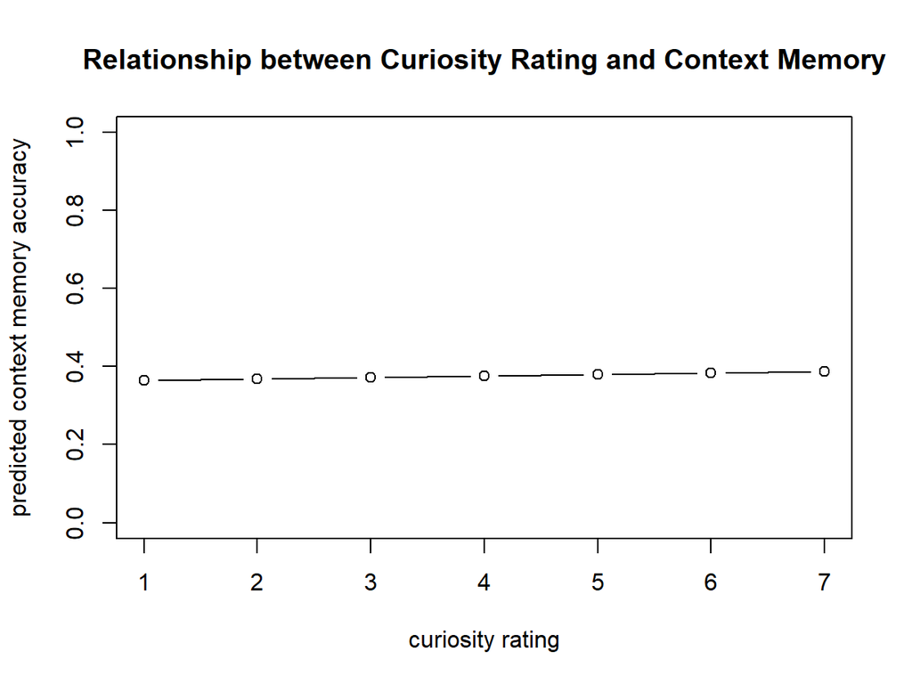

## 4.2 Does the relationship with curiosity rating depend on item order?

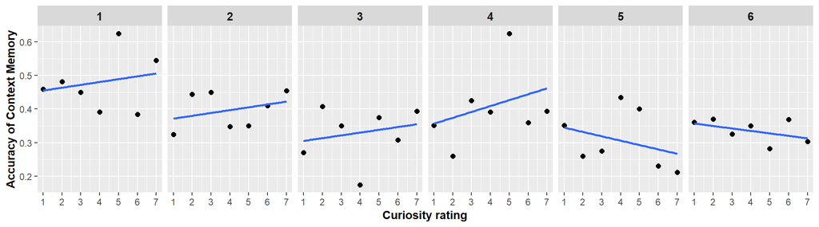

Figure 7. Mean accuracy across participants for context memory as a function of curiosity rating for each order at which the item was seen (I.e., 1st, 2nd, 3rd, etc.).

### 4.2.1 Testing the effect of item order

Build models with context memory accuracy as $y$ and examine effects of curioity rating and item order by comparing the models.

- `item.model.linear.1` is the model with $\small ItemOrder$ included (in addition to $\small CuriosityRating$), showing the effects of item order.
- `item.model.linear.2` is the model allowing the slope (i.e., relationship between context memory and item order) varying across participants.
- `item.model.linear.3` is the model with the interaction between $\small ItemOrders$ and $\small CuriosityRating$ included.
- `item.model.quad.1` and `item.model.quad.2` repectively included $\small ItemOrder^2$ and related random effects.
- `item.model.quad.3` included interaction between $\small ItemOrder^2$ and $\small CuriosityRating$ for inestigating whether the pattern changes as a function of *curiosity rating*.

```r
baseline.context <- lme(ContextAccuracy ~ 1, random = ~ 1|SubjectNo, data = Encoding.Recall.Old[! SubjectNo %in% bad.ps.less.strict], method = "ML", control = list(msMaxIter = 500, opt = "optim", msVerbose=FALSE), na.action = na.exclude)

rating.intercept <- update(baseline.context, .~. + CuriosityRating)
rating.slope     <- update(rating.intercept, random = ~ 1 + CuriosityRating | SubjectNo)

item.model.linear.1     <- update(rating.slope, .~. + ItemOrder)
item.model.linear.2     <- update(item.model.linear.1, random = list(~1+CuriosityRating + ItemOrder|SubjectNo))
item.model.linear.3     <- update(item.model.linear.2, .~. + ItemOrder : CuriosityRating)

item.model.quad.1       <- update(item.model.linear.3, .~. + I(ItemOrder^2))
# item.model.quad.2       <- update(item.model.quad.1,   random = list(~1+CuriosityRating|SubjectNo, ~1+ItemOrder+I(ItemOrder^2)|SubjectNo)) - excluding this model because singularity issue (perhaps the model was getting too complex to be calculated)
item.model.quad.3       <- update(item.model.quad.1,   .~. + I(ItemOrder^2) : CuriosityRating)

anova(baseline.context, rating.intercept, rating.slope, item.model.linear.1, item.model.linear.2, item.model.linear.3, item.model.quad.1, item.model.quad.3)
```

```
##                     Model df      AIC      BIC    logLik   Test   L.Ratio
## baseline.context        1  3 1943.969 1959.762 -968.9847
## rating.intercept        2  4 1945.614 1966.670 -968.8072 1 vs 2  0.355102
## rating.slope            3  6 1949.502 1981.086 -968.7510 2 vs 3  0.112295
## item.model.linear.1     4  7 1937.679 1974.527 -961.8395 3 vs 4 13.823022
## item.model.linear.2     5 10 1943.669 1996.309 -961.8345 4 vs 5  0.009975
## item.model.linear.3     6 11 1943.901 2001.805 -960.9504 5 vs 6  1.768185
## item.model.quad.1       7 12 1944.451 2007.620 -960.2256 6 vs 7  1.449627
## item.model.quad.3       8 13 1945.651 2014.083 -959.8255 7 vs 8  0.800186
##                     p-value
## baseline.context
## rating.intercept     0.5512
## rating.slope         0.9454
## item.model.linear.1  0.0002
## item.model.linear.2  0.9997
## item.model.linear.3  0.1836
## item.model.quad.1    0.2286
## item.model.quad.3    0.3710
```

#### 4.2.1.1 Parameter estimation for the complete model

```r
summary(item.model.quad.3)
```

```
## Linear mixed-effects model fit by maximum likelihood
##  Data: Encoding.Recall.Old[!SubjectNo %in% bad.ps.less.strict]
##        AIC      BIC    logLik
##   1945.651 2014.083 -959.8255
##
## Random effects:
##  Formula: ~1 + CuriosityRating + ItemOrder | SubjectNo
##  Structure: General positive-definite, Log-Cholesky parametrization
##                 StdDev       Corr
## (Intercept)     1.062638e-01 (Intr) CrstyR
## CuriosityRating 8.340216e-03  0.378
## ItemOrder       4.178615e-05 -0.004 -0.002
## Residual        4.654399e-01
##
## Fixed effects: ContextAccuracy ~ CuriosityRating + ItemOrder + I(ItemOrder^2) +      CuriosityRating:ItemOrder + CuriosityRating:I(ItemOrder^2)
##                                     Value  Std.Error   DF   t-value
## (Intercept)                     0.5319330 0.12241963 1383  4.345161
## CuriosityRating                 0.0013648 0.02683366 1383  0.050860
## ItemOrder                      -0.1082118 0.07929062 1383 -1.364750
## I(ItemOrder^2)                  0.0138109 0.01110095 1383  1.244122
## CuriosityRating:ItemOrder       0.0076697 0.01751808 1383  0.437814
## CuriosityRating:I(ItemOrder^2) -0.0016371 0.00245216 1383 -0.667614
##                                p-value
## (Intercept)                     0.0000
## CuriosityRating                 0.9594
## ItemOrder                       0.1726
## I(ItemOrder^2)                  0.2137
## CuriosityRating:ItemOrder       0.6616
## CuriosityRating:I(ItemOrder^2)  0.5045
##  Correlation:
##                                (Intr) CrstyR ItmOrd I(IO^2 CrR:IO
## CuriosityRating                -0.883
## ItemOrder                      -0.921  0.831
## I(ItemOrder^2)                  0.845 -0.762 -0.979
## CuriosityRating:ItemOrder       0.825 -0.929 -0.895  0.876
## CuriosityRating:I(ItemOrder^2) -0.756  0.851  0.876 -0.895 -0.979
##
## Standardized Within-Group Residuals:
##        Min         Q1        Med         Q3        Max
## -1.4669550 -0.8116180 -0.5343882  1.1370867  1.8434592
##
## Number of Observations: 1428
## Number of Groups: 40
```

Maybe because of being lack of power (too many parameters and too few participants), no parameter has a significant estimated value.

```r
#### Parameter estimation for the optimal model
summary(item.model.quad.1)
```

[output not shown]

### 4.2.2 Collapse the order and curiosity rating

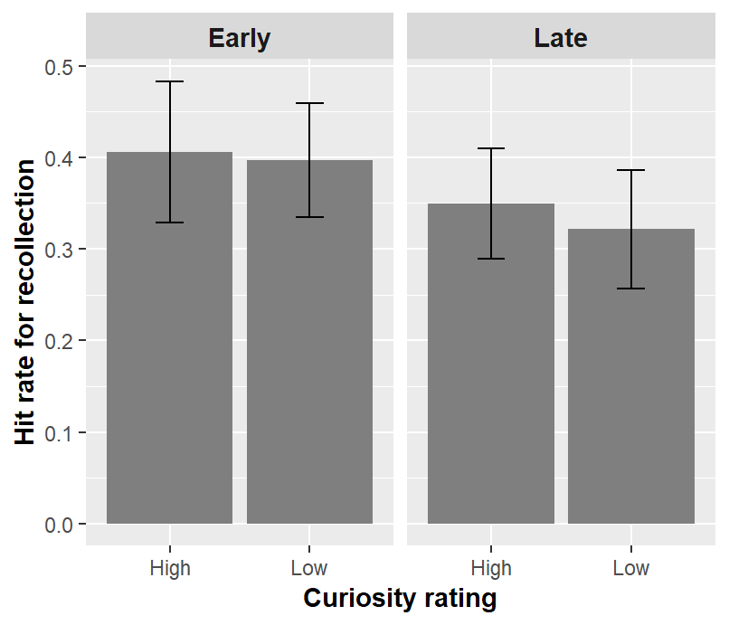

Figure 7. Mean hit rate as a function of item order (Early vs. Late) and curiosity (Low vs. High).

#### 4.2.2.1 Stats on it

```
## Linear mixed-effects model fit by maximum likelihood
##  Data: Encoding.Recall.Old.Collapsed
##         AIC       BIC   logLik
##   -72.47528 -48.07643 44.23764
##
## Random effects:
##  Formula: ~1 | SubjectNo
##         (Intercept)
## StdDev:   0.1324315
##
##  Formula: ~1 | CuriosityRatingType %in% SubjectNo
##         (Intercept)
## StdDev: 0.004212068
##
##  Formula: ~1 | ItemOrderType %in% CuriosityRatingType %in% SubjectNo
##         (Intercept)   Residual
## StdDev:   0.1514095 0.02194262
##
## Fixed effects: ContextAccuracy ~ CuriosityRatingType * ItemOrderType
##                                               Value  Std.Error DF
## (Intercept)                               0.4056944 0.03241917 76
## CuriosityRatingTypeLow                   -0.0089593 0.03525825 37
## ItemOrderTypeLate                        -0.0561905 0.03465709 76
## CuriosityRatingTypeLow:ItemOrderTypeLate -0.0191019 0.04965324 76
##                                            t-value p-value
## (Intercept)                              12.514029  0.0000
## CuriosityRatingTypeLow                   -0.254105  0.8008
## ItemOrderTypeLate                        -1.621327  0.1091
## CuriosityRatingTypeLow:ItemOrderTypeLate -0.384706  0.7015
##  Correlation:
##                                          (Intr) CrsRTL ItmOTL
## CuriosityRatingTypeLow                   -0.526
## ItemOrderTypeLate                        -0.535  0.491
## CuriosityRatingTypeLow:ItemOrderTypeLate  0.373 -0.704 -0.698
##
## Standardized Within-Group Residuals:
##          Min           Q1          Med           Q3          Max
## -0.316483694 -0.091737372  0.001382356  0.095458877  0.320005880
##
## Number of Observations: 156
## Number of Groups:
##                                             SubjectNo
##                                                    40
##                    CuriosityRatingType %in% SubjectNo
##                                                    78
## ItemOrderType %in% CuriosityRatingType %in% SubjectNo
##                                                   156
```

### 4.2.3 Try another way to calculate “High” and “Low” curiosity groups

> “High” - higher than mean; “Low” - lower than mean

#### 4.2.3.1 Compare “High” and “Low” groups

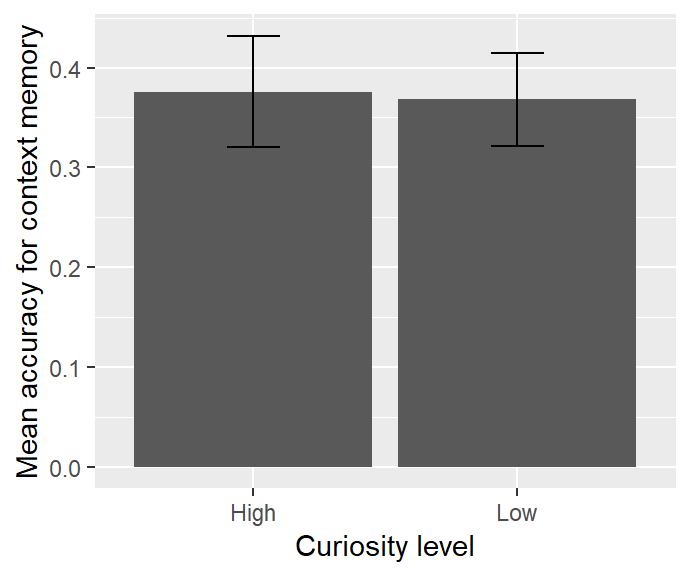

```
##
##  Paired t-test
##
## data:  ContextAccuracy by RatingGroup
## t = 0.30448, df = 39, p-value = 0.7624
## alternative hypothesis: true difference in means is not equal to 0
## 95 percent confidence interval:
##  -0.04103178  0.05557427
## sample estimates:
## mean of the differences
##             0.007271242
```

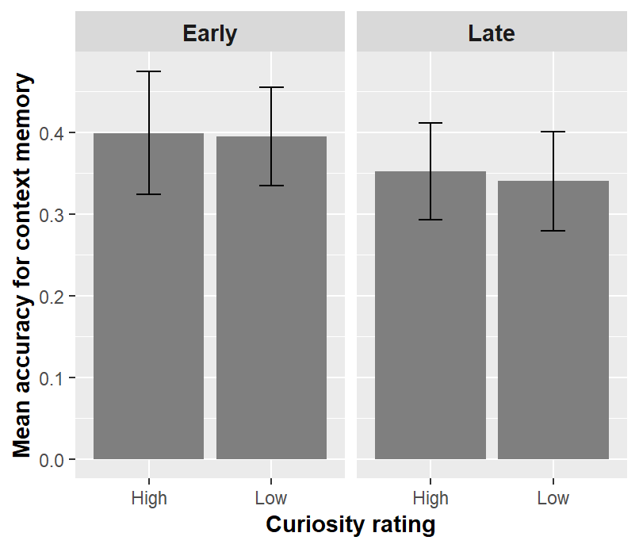

#### 4.2.3.2 Stats on it

```
## Linear mixed-effects model fit by maximum likelihood
##  Data: Encoding.Recall.Old.Collapsed.Alt[!SubjectNo %in% bad.ps.less.strict]
##         AIC       BIC   logLik
##   -84.65561 -60.05422 50.32781
##
## Random effects:
##  Formula: ~1 | SubjectNo
##         (Intercept)
## StdDev:   0.1322878
##
##  Formula: ~1 | RatingGroup %in% SubjectNo
##         (Intercept)
## StdDev:  0.01517228
##
##  Formula: ~1 | ItemOrderType %in% RatingGroup %in% SubjectNo
##         (Intercept)   Residual
## StdDev:   0.1432875 0.03284512
##
## Fixed effects: ContextAccuracy ~ RatingGroup * ItemOrderType
##                                       Value  Std.Error DF   t-value
## (Intercept)                       0.3993056 0.03176047 78 12.572407
## RatingGroupLow                   -0.0041667 0.03346664 39 -0.124502
## ItemOrderTypeLate                -0.0470238 0.03328980 78 -1.412559
## RatingGroupLow:ItemOrderTypeLate -0.0078373 0.04707889 78 -0.166472
##                                  p-value
## (Intercept)                       0.0000
## RatingGroupLow                    0.9016
## ItemOrderTypeLate                 0.1618
## RatingGroupLow:ItemOrderTypeLate  0.8682
##  Correlation:
##                                  (Intr) RtngGL ItmOTL
## RatingGroupLow                   -0.527
## ItemOrderTypeLate                -0.524  0.497
## RatingGroupLow:ItemOrderTypeLate  0.371 -0.703 -0.707
##
## Standardized Within-Group Residuals:
##         Min          Q1         Med          Q3         Max
## -0.49394614 -0.13971362 -0.00270393  0.15809117  0.56795587
##
## Number of Observations: 160
## Number of Groups:
##                                     SubjectNo
##                                            40
##                    RatingGroup %in% SubjectNo
##                                            80
## ItemOrderType %in% RatingGroup %in% SubjectNo
##                                           160
```

##### 4.2.3.2.1 Simple effects in “Early”

```r
t.test(ContextAccuracy ~ RatingGroup, data = Encoding.Recall.Old.Collapsed.Alt[!SubjectNo %in% c(bad.ps.less.strict) & ItemOrderType == "Early"], paired = T)
```

```
##
##  Paired t-test
##
## data:  ContextAccuracy by RatingGroup
## t = 0.11267, df = 39, p-value = 0.9109
## alternative hypothesis: true difference in means is not equal to 0
## 95 percent confidence interval:
##  -0.07063653  0.07896986
## sample estimates:
## mean of the differences
##             0.004166667
```

# 5 Curiosity and novelty

## 5.1 Testing the effects of curiosity rating and novelty together

Build models with context memory accuracy as $y$ and examine effects of curiosity rating and novelty together by including them into the model separately and then comparing the model fits.

```
##                   Model df       AIC        BIC   logLik   Test   L.Ratio
## baseline.rating       1  4 -27.32401 -13.418160 17.66201
## rating.intercept      2  5 -25.64831  -8.265993 17.82416 1 vs 2 0.3242959
## rating.slope          3  9 -17.65085  13.637320 17.82543 2 vs 3 0.0025415
## novelty.model         4 10 -17.13877  17.625864 18.56939 3 vs 4 1.4879196
## interaction.model     5 11 -16.26349  21.977608 19.13175 4 vs 5 1.1247197
##                   p-value
## baseline.rating
## rating.intercept   0.5690
## rating.slope       1.0000
## novelty.model      0.2225
## interaction.model  0.2889
```

### 5.1.1 Check the complete model

```
## Linear mixed-effects model fit by maximum likelihood
##  Data: InsideObjectsMemory
##         AIC      BIC   logLik
##   -16.26349 21.97761 19.13175
##
## Random effects:
##  Formula: ~1 + CuriosityRating | SubjectNo
##  Structure: General positive-definite, Log-Cholesky parametrization
##                 StdDev       Corr
## (Intercept)     1.232576e-01 (Intr)
## CuriosityRating 8.061272e-05 -0.001
##
##  Formula: ~1 + CuriosityRating | Group %in% SubjectNo
##  Structure: General positive-definite, Log-Cholesky parametrization
##                 StdDev       Corr
## (Intercept)     1.059290e-03 (Intr)
## CuriosityRating 8.621266e-05 -0.005
## Residual        2.025778e-01
##
## Fixed effects: ContextAccuracy ~ CuriosityRating + Group + CuriosityRating:Group
##                                  Value  Std.Error  DF   t-value p-value
## (Intercept)                 0.31609365 0.04687539 157  6.743275  0.0000
## CuriosityRating             0.02544551 0.01509939 157  1.685201  0.0939
## GroupNovel                  0.05045619 0.10370675  39  0.486528  0.6293
## CuriosityRating:GroupNovel -0.02450791 0.02281171 157 -1.074356  0.2843
##  Correlation:
##                            (Intr) CrstyR GrpNvl
## CuriosityRating            -0.816
## GroupNovel                 -0.414  0.420
## CuriosityRating:GroupNovel  0.575 -0.705 -0.914
##
## Standardized Within-Group Residuals:
##         Min          Q1         Med          Q3         Max
## -2.07703248 -0.69981272 -0.04840391  0.62992123  3.04753125
##
## Number of Observations: 239
## Number of Groups:
##            SubjectNo Group %in% SubjectNo
##                   40                   80
```

## 5.2 What about the other way around

```
##                   Model df      AIC      BIC    logLik   Test   L.Ratio
## baseline.context      1  3 1943.969 1959.762 -968.9847
## novelty.model         2  4 1945.856 1966.912 -968.9280 1 vs 2 0.1133969
## rating.model.1        3  5 1945.975 1972.295 -967.9875 2 vs 3 1.8810534
## rating.model.2        4 10 1955.433 2008.074 -967.7167 3 vs 4 0.5415623
## interaction.model     5 11 1956.148 2014.052 -967.0739 4 vs 5 1.2855769
##                   p-value
## baseline.context
## novelty.model      0.7363
## rating.model.1     0.1702
## rating.model.2     0.9905
## interaction.model  0.2569
```

## 5.3 Check the collapsed data

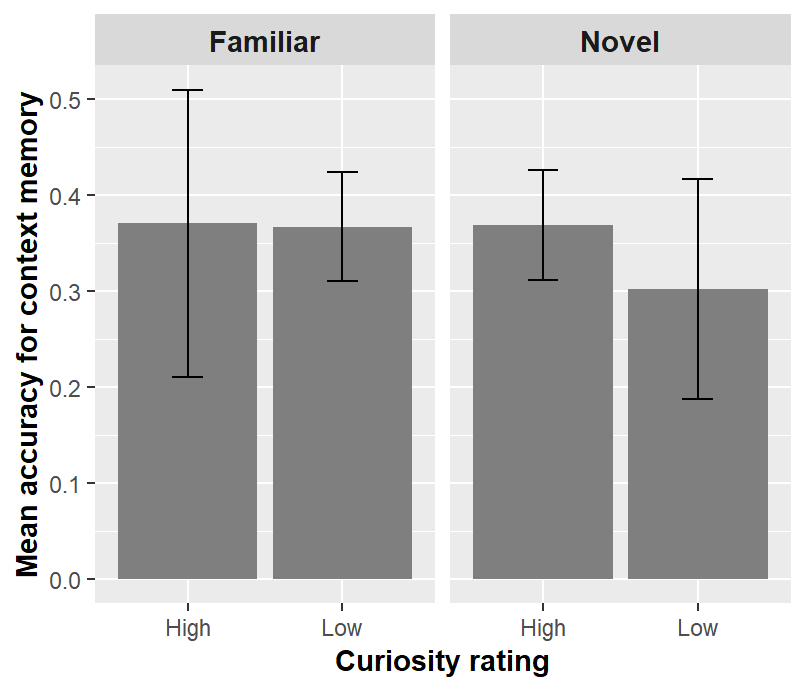

#### 5.3.0.1 Stats on it

```
## Linear mixed-effects model fit by maximum likelihood
##  Data: Encoding.Recall.Old.Collapsed.Interaction[!SubjectNo %in% bad.ps.less.strict]
##        AIC       BIC   logLik
##   -65.6901 -45.34375 40.84505
##
## Random effects:
##  Formula: ~1 | SubjectNo
##         (Intercept)
## StdDev:   0.1351102
##
##  Formula: ~1 | CuriosityRatingType %in% SubjectNo
##         (Intercept)
## StdDev: 0.001457452
##
##  Formula: ~1 | Group %in% CuriosityRatingType %in% SubjectNo
##         (Intercept)   Residual
## StdDev:   0.1153481 0.01148835
##
## Fixed effects: ContextAccuracy ~ CuriosityRatingType * Group
##                                        Value  Std.Error DF   t-value
## (Intercept)                        0.4059546 0.04995852 39  8.125833
## CuriosityRatingTypeLow            -0.0414397 0.04959483 37 -0.835564
## GroupNovel                        -0.0382457 0.04905549 14 -0.779641
## CuriosityRatingTypeLow:GroupNovel  0.0208525 0.07382733 14  0.282450
##                                   p-value
## (Intercept)                        0.0000
## CuriosityRatingTypeLow             0.4088
## GroupNovel                         0.4486
## CuriosityRatingTypeLow:GroupNovel  0.7817
##  Correlation:
##                                   (Intr) CrsRTL GrpNvl
## CuriosityRatingTypeLow            -0.828
## GroupNovel                        -0.829  0.848
## CuriosityRatingTypeLow:GroupNovel  0.606 -0.721 -0.725
##
## Standardized Within-Group Residuals:
##          Min           Q1          Med           Q3          Max
## -0.178391781 -0.068912483  0.004759965  0.062704611  0.161807552
##
## Number of Observations: 94
## Number of Groups:
##                                     SubjectNo
##                                            40
##            CuriosityRatingType %in% SubjectNo
##                                            78
## Group %in% CuriosityRatingType %in% SubjectNo
##                                            94
```

### 5.3.1 Alternative way to collapse data

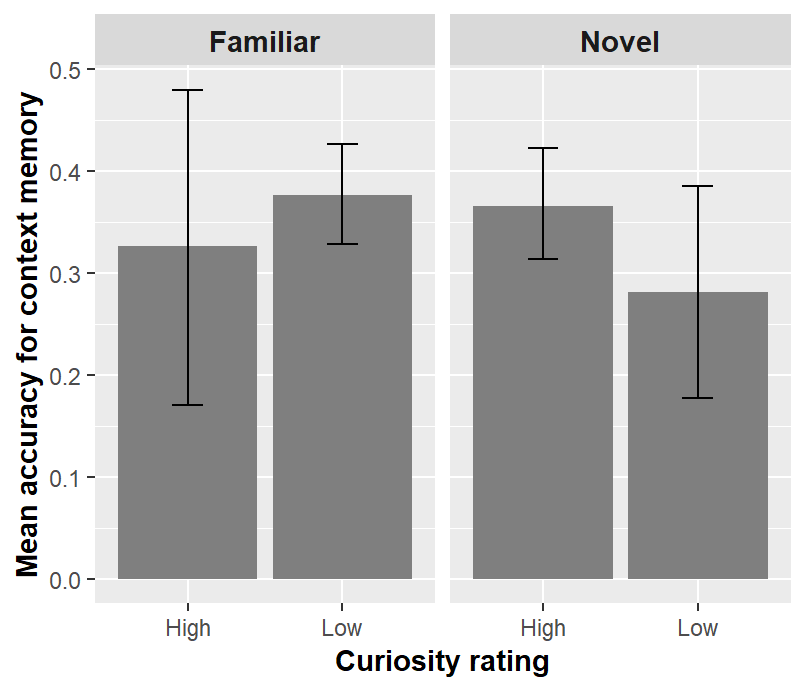

```
## Linear mixed-effects model fit by maximum likelihood
##  Data: Encoding.Recall.Old.Collapsed.Alt.Interaction[!SubjectNo %in%      bad.ps.less.strict]
##         AIC       BIC   logLik
##   -71.24822 -50.73344 43.62411
##
## Random effects:
##  Formula: ~1 | SubjectNo
##         (Intercept)
## StdDev:   0.1328873
##
##  Formula: ~1 | RatingGroup %in% SubjectNo
##         (Intercept)
## StdDev: 0.002821677
##
##  Formula: ~1 | Group %in% RatingGroup %in% SubjectNo
##         (Intercept)   Residual
## StdDev:   0.1132516 0.01418201
##
## Fixed effects: ContextAccuracy ~ RatingGroup * Group
##                                Value  Std.Error DF   t-value p-value
## (Intercept)                0.3986232 0.05124271 39  7.779119  0.0000
## RatingGroupLow            -0.0220954 0.05005187 39 -0.441450  0.6613
## GroupNovel                -0.0330676 0.05004772 14 -0.660722  0.5195
## RatingGroupLow:GroupNovel -0.0085767 0.07547130 14 -0.113642  0.9111
##  Correlation:
##                           (Intr) RtngGL GrpNvl
## RatingGroupLow            -0.844
## GroupNovel                -0.844  0.864
## RatingGroupLow:GroupNovel  0.649 -0.754 -0.754
##
## Standardized Within-Group Residuals:
##         Min          Q1         Med          Q3         Max
## -0.20525797 -0.08081686  0.01882753  0.07136461  0.21680788
##
## Number of Observations: 96
## Number of Groups:
##                             SubjectNo
##                                    40
##            RatingGroup %in% SubjectNo
##                                    80
## Group %in% RatingGroup %in% SubjectNo
##                                    96
```

# 6 Curiosity effects in the *Novel* group

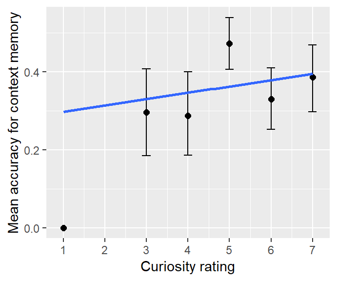